# Chapther 4: Introduction to R, Rstudio and ggplot

Haydeé Peruyero

2022-08-31

Cargamos la tabla de abundancia

```r
abund_table = read.csv("D:/Users/hayde/Documents/R_sites/Analisis_estadistico_de_datos_de_Microbioma_con_R/data/ALSG93AGenus.csv",row.names=1, check.names=FALSE)
abund_table_t<-t(abund_table)
```

calculamos la diversidad Shannon

```r
library(vegan)
```

Se usa la funcion diversidad del paquete vegan para calcular el indice Shannon Se realiza el dataframe del indice de Shannnon

```r
H<-diversity(abund_table_t, "shannon")
df_H<-data.frame(sample=names(H),value=H,measure=rep("Shannon", length(H)))
```

Se obtiene la informacion agrupada para los datps de la muestra

```r
df_H$Group <- with(df_H, ifelse(as.factor(sample)%in% c("A11-28F","A12-28F",
"A13-28F","A14-28F","A15-28F","A16-28F"),c("G93m1"),
ifelse(as.factor(sample)%in% c("A21-28F","A22-28F","A23-28F","A24-28F",
                               "A25-28F","A26-28F"),c("WTm1"),
       ifelse(as.factor(sample)%in% c("C11-28F","C12-28F","C13-28F"),c("G93m4"),
              ifelse(as.factor(sample)%in% c("C21-28F","C22-28F","C23-28F"),
                     c("WTm4"),ifelse(as.factor(sample)%in% c("B11-28F",
                     "B12-28F","B13-28F","B14-28F","B15-28F","D11-28F",
                     "D12-28F","D13-28F","D14-28F"),c("BUm3to3.5"),
                     c("NOBUm3to3.5")))))))
```

```r
head(df_H)
```

```
##          sample    value measure Group
## A11-28F A11-28F 2.478397 Shannon G93m1
## A12-28F A12-28F 2.162110 Shannon G93m1
## A13-28F A13-28F 1.706873 Shannon G93m1
## A14-28F A14-28F 2.084189 Shannon G93m1
## A15-28F A15-28F 2.659529 Shannon G93m1
## A16-28F A16-28F 1.970920 Shannon G93m1
```

El conjunto de datos incluye datos de muestra de los meses 1, 3, 3,5 y 4. Nos interesa en las comparaciones del tratamiento frente al no tratamiento durante los meses 3 y 3,5. Así que los datos de 3 a 3,5 meses como se indica a continuación:

```r
library(dplyr)
df_H_G6 <- select(df_H, Group,value)
df_H_G93BUm3 <- filter(df_H_G6,Group=="BUm3to3.5"|Group=="NOBUm3to3.5")
df_H_G93BUm3
```

```
##               Group    value
## B11-28F   BUm3to3.5 2.393363
## B12-28F   BUm3to3.5 2.676597
## B13-28F   BUm3to3.5 2.256956
## B14-28F   BUm3to3.5 2.699827
## B15-28F   BUm3to3.5 2.580291
## B21-28F NOBUm3to3.5 2.262372
## B22-28F NOBUm3to3.5 2.230096
## B23-28F NOBUm3to3.5 2.432948
## B24-28F NOBUm3to3.5 2.049187
## B25-28F NOBUm3to3.5 1.813794
## D11-28F   BUm3to3.5 2.626051
## D12-28F   BUm3to3.5 2.334286
## D13-28F   BUm3to3.5 2.343880
## D14-28F   BUm3to3.5 2.625499
## D21-28F NOBUm3to3.5 2.332629
## D22-28F NOBUm3to3.5 2.311971
```

Graficar

```r
library(ggplot2)
#dividir la trama en múltiples paneles
p<-ggplot(df_H_G93BUm3, aes(x=value))+
  geom_histogram(color="black",fill="black")+
  facet_grid(Group ~ .)
```

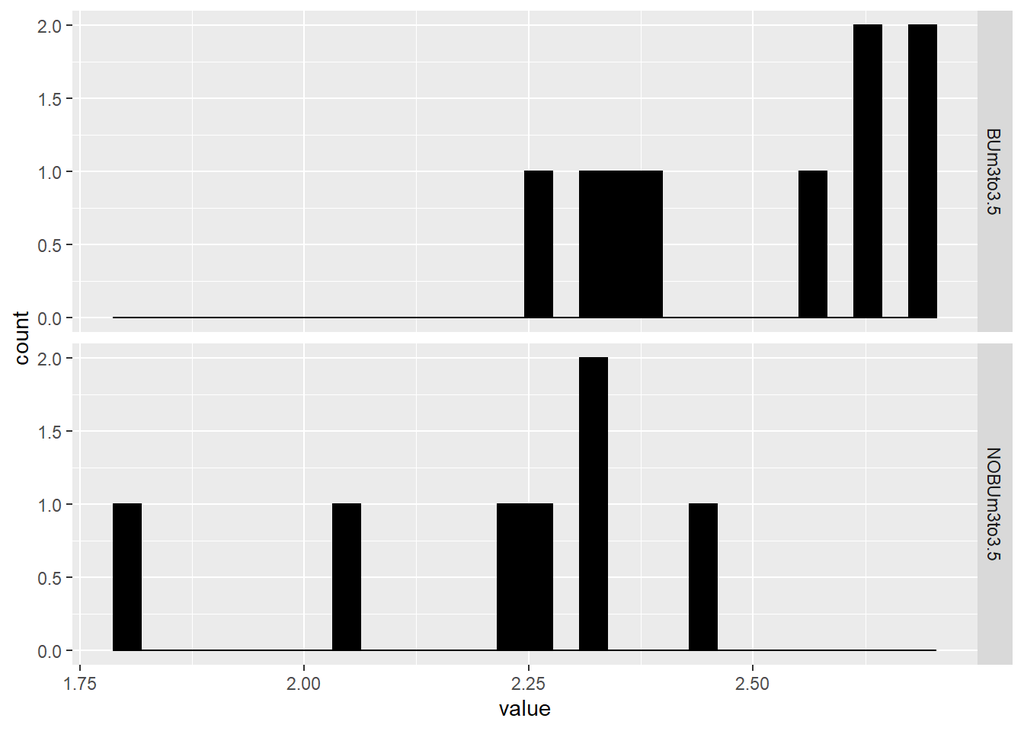

```r
p
```

Calcular la media de cada grupo calcular la diversidad promedio de Shannon de cada grupo usando el paquete Plyr

```r
library(plyr)
mu <- ddply(df_H_G93BUm3, "Group", summarise, grp.mean=mean(value))
head(mu)
```

```
##         Group grp.mean
## 1   BUm3to3.5 2.504083
## 2 NOBUm3to3.5 2.204714
```

agrega las lineas de la media

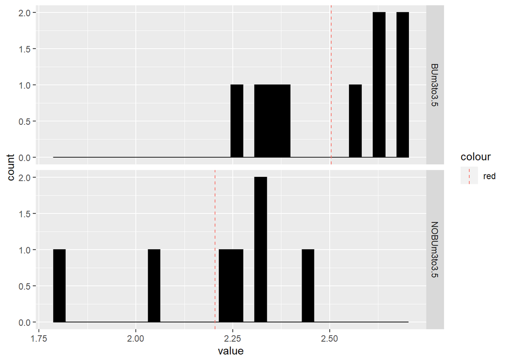

```r
p+geom_vline(data=mu, aes(xintercept=grp.mean, color="red"),
             linetype="dashed")
```

##5.2.3 Cálculo de la potencia o el tamaño de la muestra mediante la función R power.t.test Dado que se desconoce la desviación estándar de la diferencia de medias, es necesario estimarlo

```r
aggregate(value ~ Group,
          df_H_G93BUm3,
          mean)
```

```
##         Group    value
## 1   BUm3to3.5 2.504083
## 2 NOBUm3to3.5 2.204714
```